# Mattia Piazzon - Esercizio 4

# 1 Punto 1

Leggiamo e visualizziamo i dati:

```r
setwd("~/MEGAsync/Universita/II Anno/Analisi dei Dati/Esami/PrimoAppello")
library(car)
mammiferi <- read.csv("mammiferi.csv")
head(mammiferi)
```

|  | gestazione | ore_sogno |
| --- | --- | --- |
| 1 | 164 | 1.2 |
| 2 | 120 | 1.2 |
| 3 | 16 | 3.4 |
| 4 | 63 | 3.6 |
| 5 | 52 | 2.4 |
| 6 | 281 | 0.7 |

Visualizzo i dati tramite grafico:

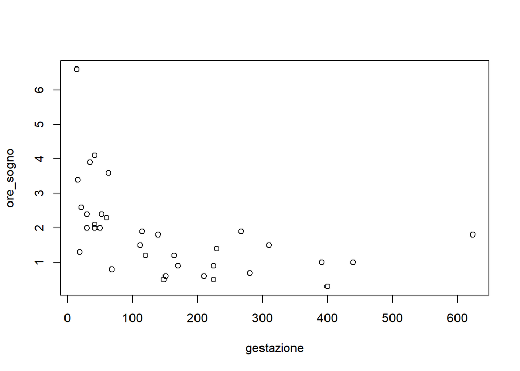

```r
plot(ore_sogno ~ gestazione, data = mammiferi)
```

Noto che il grafico non è di facile interpretazione e inoltre ci sono dati che si discostano dagli altri.

Creo comunque il modello di regressione:

```r
mod <- lm(ore_sogno ~ gestazione, data = mammiferi)
summary(mod)
```

```
##
## Call:
## lm(formula = ore_sogno ~ gestazione, data = mammiferi)
##
## Residuals:
##     Min      1Q  Median      3Q     Max
## -1.4221 -0.6391 -0.1804  0.2810  4.1463
##
## Coefficients:
##              Estimate Std. Error t value Pr(>|t|)
## (Intercept)  2.513709   0.291647   8.619 7.54e-10 ***
## gestazione  -0.004289   0.001376  -3.118  0.00383 **
## ---
## Signif. codes:  0 '***' 0.001 '**' 0.01 '*' 0.05 '.' 0.1 ' ' 1
##
## Residual standard error: 1.151 on 32 degrees of freedom
## Multiple R-squared:  0.233,  Adjusted R-squared:  0.2091
## F-statistic: 9.723 on 1 and 32 DF,  p-value: 0.003833
```

Analizzo i residui:

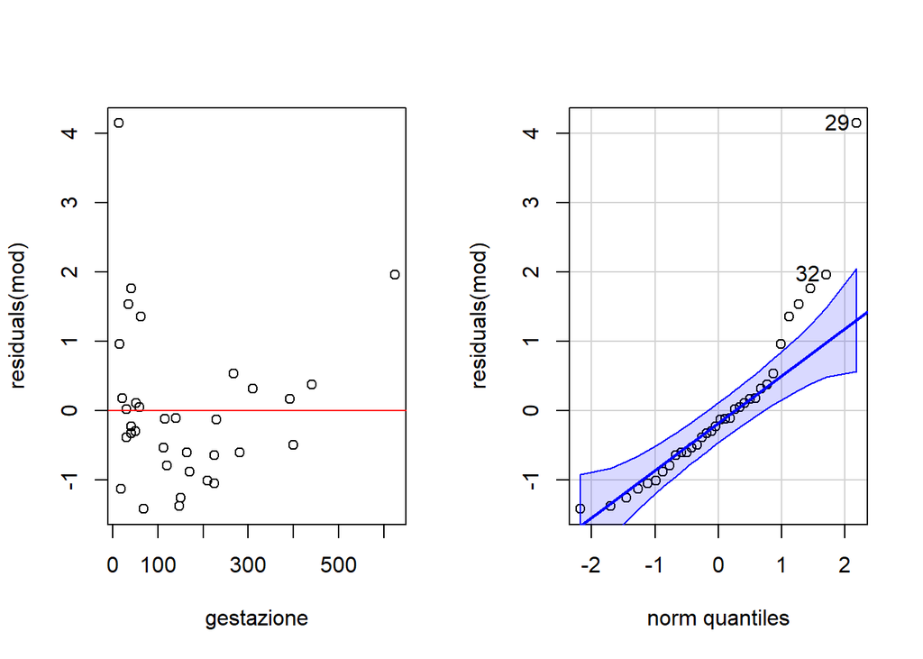

```
## [1] 29 32
```

```r
par(mfrow = c(1, 2))
plot(residuals(mod) ~ gestazione, data = mammiferi)
abline(h = 0, col = "red")
qqPlot(residuals(mod))
```

Facendo l’analisi dei residui noto che il modello non è appropriato.

Provo a trasformarlo in scala logaritmica:

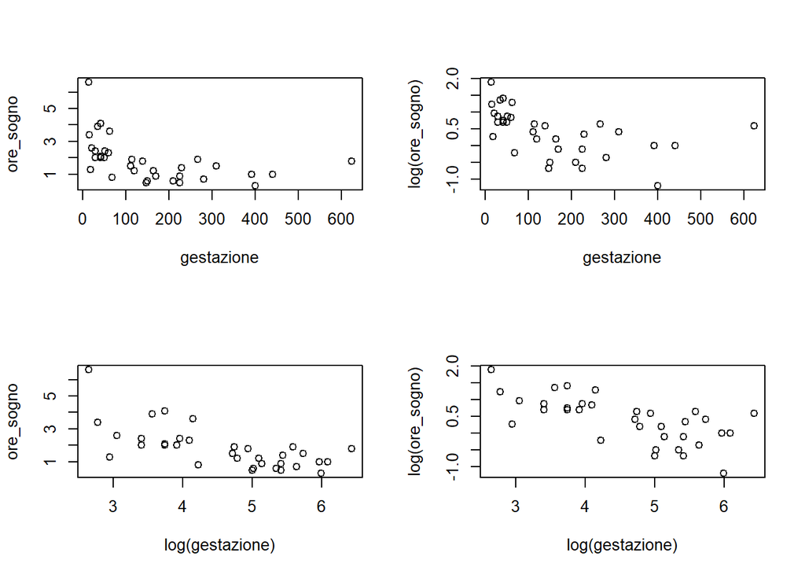

```r
par(mfrow = c(2, 2))
plot(ore_sogno ~ gestazione, data = mammiferi)
plot(log(ore_sogno) ~ gestazione, data = mammiferi)
plot(ore_sogno ~ log(gestazione), data = mammiferi)
plot(log(ore_sogno) ~ log(gestazione), data = mammiferi)
```

```r
par(mfrow = c(1, 1))
```

Noto che il terzo sembra il più appropriato. Costruisco il modello:

```r
mod_log <- lm(ore_sogno ~ log(gestazione), data = mammiferi)
summary(mod_log)
```

```
##
## Call:
## lm(formula = ore_sogno ~ log(gestazione), data = mammiferi)
##
## Residuals:
##     Min      1Q  Median      3Q     Max
## -1.9036 -0.5116 -0.2416  0.2980  3.1430
##
## Coefficients:
##                 Estimate Std. Error t value Pr(>|t|)
## (Intercept)       5.6475     0.7555   7.475 1.65e-08 ***
## log(gestazione)  -0.8300     0.1608  -5.161 1.24e-05 ***
## ---
## Signif. codes:  0 '***' 0.001 '**' 0.01 '*' 0.05 '.' 0.1 ' ' 1
##
## Residual standard error: 0.9707 on 32 degrees of freedom
## Multiple R-squared:  0.4542, Adjusted R-squared:  0.4372
## F-statistic: 26.63 on 1 and 32 DF,  p-value: 1.245e-05
```

Faccio l’analisi dei residui:

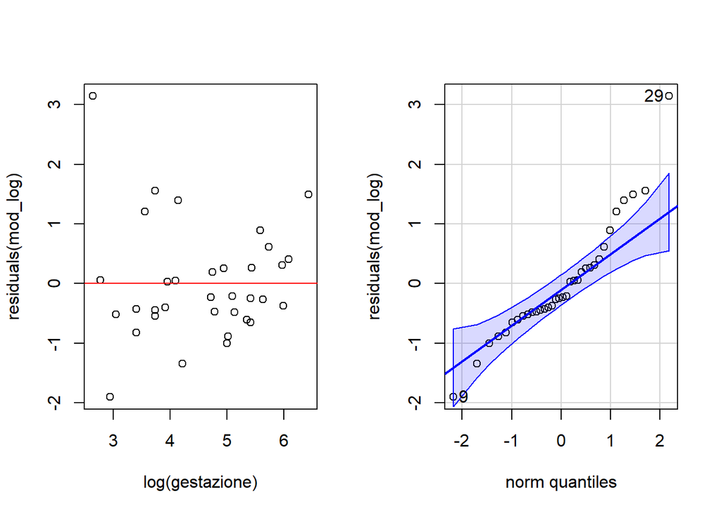

```
## [1] 29  9
```

```r
par(mfrow = c(1, 2))
plot(residuals(mod_log) ~ log(gestazione), data = mammiferi)
abline(h = 0, col = "red")
qqPlot(residuals(mod_log))
```

Dato R^2 aggiustato e dall’analisi dei residui noto che il modello è migliore, nonostante ci sia una sottostima alla coda.

Provo ad aggiungere un termine quadratico:

```r
mod_quad <- lm(ore_sogno ~ log(gestazione) + I(log(gestazione)^2), data = mammiferi)
summary(mod_quad)
```

```
##
## Call:
## lm(formula = ore_sogno ~ log(gestazione) + I(log(gestazione)^2),
##     data = mammiferi)
##
## Residuals:
##     Min      1Q  Median      3Q     Max
## -2.3353 -0.5452 -0.1529  0.4335  2.3708
##
## Coefficients:
##                      Estimate Std. Error t value Pr(>|t|)
## (Intercept)           11.9086     3.0499   3.905 0.000476 ***
## log(gestazione)       -3.7749     1.4025  -2.691 0.011364 *
## I(log(gestazione)^2)   0.3278     0.1552   2.112 0.042825 *
## ---
## Signif. codes:  0 '***' 0.001 '**' 0.01 '*' 0.05 '.' 0.1 ' ' 1
##
## Residual standard error: 0.9221 on 31 degrees of freedom
## Multiple R-squared:  0.5229, Adjusted R-squared:  0.4921
## F-statistic: 16.99 on 2 and 31 DF,  p-value: 1.043e-05
```

Faccio l’analisi dei residui:

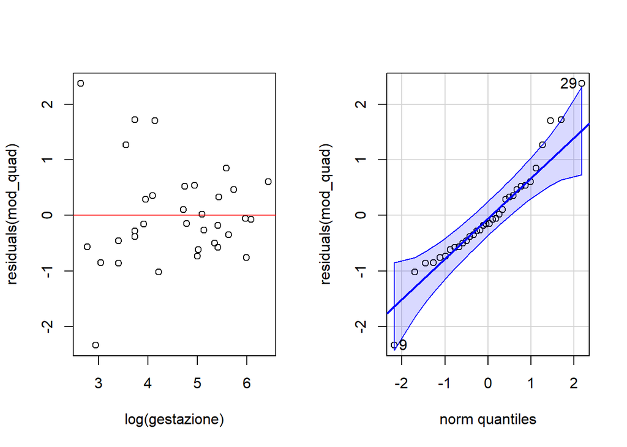

```
## [1] 29  9
```

```r
par(mfrow = c(1, 2))
plot(residuals(mod_quad) ~ log(gestazione), data = mammiferi)
abline(h = 0, col = "red")
qqPlot(residuals(mod_quad))
```

Provo a vedere se migliora aggiungendo un termine cubuco:

```r
mod_cub <- lm(ore_sogno ~ log(gestazione) + I(log(gestazione)^2) + I(log(gestazione)^3), data = mammiferi)
summary(mod_cub)
```

```
##
## Call:
## lm(formula = ore_sogno ~ log(gestazione) + I(log(gestazione)^2) +
##     I(log(gestazione)^3), data = mammiferi)
##
## Residuals:
##     Min      1Q  Median      3Q     Max
## -2.3203 -0.5099 -0.1420  0.4465  2.4465
##
## Coefficients:
##                      Estimate Std. Error t value Pr(>|t|)
## (Intercept)           9.50614   12.13479   0.783    0.440
## log(gestazione)      -2.05425    8.52270  -0.241    0.811
## I(log(gestazione)^2) -0.06722    1.93531  -0.035    0.973
## I(log(gestazione)^3)  0.02921    0.14263   0.205    0.839
##
## Residual standard error: 0.9367 on 30 degrees of freedom
## Multiple R-squared:  0.5236, Adjusted R-squared:  0.4759
## F-statistic: 10.99 on 3 and 30 DF,  p-value: 4.926e-05
```

Noto che R^2 aggiustato è minore quindi mi fermo al modello quadratico.

Visualizzo il modello stimato:

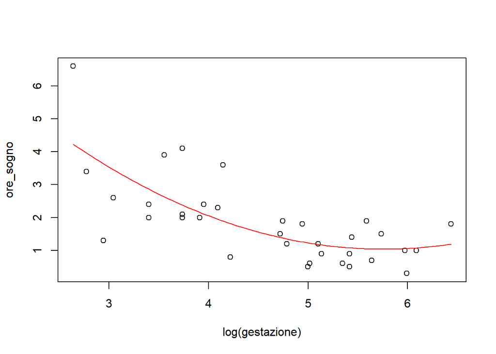

```r
par(mfrow = c(1, 1))
plot(ore_sogno ~ log(gestazione), data = mammiferi)
curve(coef(mod_quad)[1] + coef(mod_quad)[2] * x + coef(mod_quad)[3] * x ^ 2, add = TRUE, col = "red")
```

Il modello stimato spiega il 52.29% della variabilità dei dati.

# 2 Punto 2

Calcoliamo l’intervallo di previsione al 93% per il numero di ore sognate da un mammifero che ha una gestazione di 9 mesi:

```r
pred <- predict(mod_quad, newdata = data.frame(gestazione = 9 * 30), interval = "prediction", level = 0.93)
exp(pred)
```

```
##        fit      lwr      upr
## 1 2.851495 0.480766 16.91264
```

Se il mammifero avesse una gestazione di 3 mesi:

```r
pred <- predict(mod_quad, newdata = data.frame(gestazione = 3 * 30), interval = "prediction", level = 0.93)
exp(pred)
```

```
##       fit       lwr      upr
## 1 4.75337 0.7985667 28.29385
```